# JHU Coursera Practical Machine Learning Course Project

Ricardo J. Serrano

8/10/2019

## Introduction

The goal of this project is to predict the manner in which 6 participants are performing different specific exercises from wearable devices accelerometer data. The participants were asked to perform one set of 10 repetitions of the Unilateral Dumbbell Biceps Curl in five different fashions: exactly according to the specification (Class A), throwing the elbows to the front (Class B), lifting the dumbbell only halfway (Class C), lowering the dumbbell only halfway (Class D) and throwing the hips to the front (Class E). Class A corresponds to the specified execution of the exercise, while the other 4 classes correspond to common mistakes. The data from this project came from this source: http://groupware.les.inf.puc-rio.br/har.

## Reading the data

```r
train_data <- read.csv(url("https://d396qusza40orc.cloudfront.net/predmachlearn/pml-training.csv"))

test_data <- read.csv(url("https://d396qusza40orc.cloudfront.net/predmachlearn/pml-testing.csv"))
```

## Exploratory Data Analysis

```r
dim(train_data)
```

```
## [1] 19622   160
```

```r
dim(test_data)
```

```
## [1]  20 160
```

```r
str(train_data)
```

```
## 'data.frame':    19622 obs. of  160 variables:
##  $ X                       : int  1 2 3 4 5 6 7 8 9 10 ...
##  $ user_name               : Factor w/ 6 levels "adelmo","carlitos",..: 2 2 2 2 2 2 2 2 2 2 ...
##  $ raw_timestamp_part_1    : int  1323084231 1323084231 1323084231 1323084232 1323084232 1323084232 1323084232 1323084232 1323084232 1323084232 ...
##  $ raw_timestamp_part_2    : int  788290 808298 820366 120339 196328 304277 368296 440390 484323 484434 ...
##  $ cvtd_timestamp          : Factor w/ 20 levels "02/12/2011 13:32",..: 9 9 9 9 9 9 9 9 9 9 ...
##  $ new_window              : Factor w/ 2 levels "no","yes": 1 1 1 1 1 1 1 1 1 1 ...
##  $ num_window              : int  11 11 11 12 12 12 12 12 12 12 ...
##  $ roll_belt               : num  1.41 1.41 1.42 1.48 1.48 1.45 1.42 1.42 1.43 1.45 ...
##  $ pitch_belt              : num  8.07 8.07 8.07 8.05 8.07 8.06 8.09 8.13 8.16 8.17 ...
##  $ yaw_belt                : num  -94.4 -94.4 -94.4 -94.4 -94.4 -94.4 -94.4 -94.4 -94.4 -94.4 ...
##  $ total_accel_belt        : int  3 3 3 3 3 3 3 3 3 3 ...
##  $ kurtosis_roll_belt      : Factor w/ 397 levels "","-0.016850",..: 1 1 1 1 1 1 1 1 1 1 ...
##  $ kurtosis_picth_belt     : Factor w/ 317 levels "","-0.021887",..: 1 1 1 1 1 1 1 1 1 1 ...
##  $ kurtosis_yaw_belt       : Factor w/ 2 levels "","#DIV/0!": 1 1 1 1 1 1 1 1 1 1 ...
```

[output cut: 86 more lines]

```r
str(test_data)
```

```
## 'data.frame':    20 obs. of  160 variables:
##  $ X                       : int  1 2 3 4 5 6 7 8 9 10 ...
##  $ user_name               : Factor w/ 6 levels "adelmo","carlitos",..: 6 5 5 1 4 5 5 5 2 3 ...
##  $ raw_timestamp_part_1    : int  1323095002 1322673067 1322673075 1322832789 1322489635 1322673149 1322673128 1322673076 1323084240 1322837822 ...
##  $ raw_timestamp_part_2    : int  868349 778725 342967 560311 814776 510661 766645 54671 916313 384285 ...
##  $ cvtd_timestamp          : Factor w/ 11 levels "02/12/2011 13:33",..: 5 10 10 1 6 11 11 10 3 2 ...
##  $ new_window              : Factor w/ 1 level "no": 1 1 1 1 1 1 1 1 1 1 ...
##  $ num_window              : int  74 431 439 194 235 504 485 440 323 664 ...
##  $ roll_belt               : num  123 1.02 0.87 125 1.35 -5.92 1.2 0.43 0.93 114 ...
##  $ pitch_belt              : num  27 4.87 1.82 -41.6 3.33 1.59 4.44 4.15 6.72 22.4 ...
##  $ yaw_belt                : num  -4.75 -88.9 -88.5 162 -88.6 -87.7 -87.3 -88.5 -93.7 -13.1 ...
##  $ total_accel_belt        : int  20 4 5 17 3 4 4 4 4 18 ...
##  $ kurtosis_roll_belt      : logi  NA NA NA NA NA NA ...
##  $ kurtosis_picth_belt     : logi  NA NA NA NA NA NA ...
##  $ kurtosis_yaw_belt       : logi  NA NA NA NA NA NA ...
```

[output cut: 86 more lines]

The raw training dataset has 19622 records with 160 variables (columns). The raw testing has 20 records with the same number of columns. From the str output, there are several variables with NAs or blanks.

Print variables with NAs or blanks ("") percentage greater than 0.8

```r
which(colMeans(is.na(train_data) | train_data == "") > 0.8)
```

```
##       kurtosis_roll_belt      kurtosis_picth_belt        kurtosis_yaw_belt
##                       12                       13                       14
##       skewness_roll_belt     skewness_roll_belt.1        skewness_yaw_belt
##                       15                       16                       17
##            max_roll_belt           max_picth_belt             max_yaw_belt
##                       18                       19                       20
##            min_roll_belt           min_pitch_belt             min_yaw_belt
##                       21                       22                       23
##      amplitude_roll_belt     amplitude_pitch_belt       amplitude_yaw_belt
##                       24                       25                       26
##     var_total_accel_belt            avg_roll_belt         stddev_roll_belt
##                       27                       28                       29
##            var_roll_belt           avg_pitch_belt        stddev_pitch_belt
##                       30                       31                       32
##           var_pitch_belt             avg_yaw_belt          stddev_yaw_belt
##                       33                       34                       35
##             var_yaw_belt            var_accel_arm             avg_roll_arm
##                       36                       50                       51
##          stddev_roll_arm             var_roll_arm            avg_pitch_arm
##                       52                       53                       54
##         stddev_pitch_arm            var_pitch_arm              avg_yaw_arm
##                       55                       56                       57
##           stddev_yaw_arm              var_yaw_arm        kurtosis_roll_arm
##                       58                       59                       69
##       kurtosis_picth_arm         kurtosis_yaw_arm        skewness_roll_arm
##                       70                       71                       72
##       skewness_pitch_arm         skewness_yaw_arm             max_roll_arm
##                       73                       74                       75
##            max_picth_arm              max_yaw_arm             min_roll_arm
##                       76                       77                       78
##            min_pitch_arm              min_yaw_arm       amplitude_roll_arm
##                       79                       80                       81
##      amplitude_pitch_arm        amplitude_yaw_arm   kurtosis_roll_dumbbell
##                       82                       83                       87
##  kurtosis_picth_dumbbell    kurtosis_yaw_dumbbell   skewness_roll_dumbbell
##                       88                       89                       90
##  skewness_pitch_dumbbell    skewness_yaw_dumbbell        max_roll_dumbbell
##                       91                       92                       93
##       max_picth_dumbbell         max_yaw_dumbbell        min_roll_dumbbell
##                       94                       95                       96
```

[output cut: 13 more lines]

```
##                      128                      129                      130
##         max_roll_forearm        max_picth_forearm          max_yaw_forearm
##                      131                      132                      133
##         min_roll_forearm        min_pitch_forearm          min_yaw_forearm
##                      134                      135                      136
##   amplitude_roll_forearm  amplitude_pitch_forearm    amplitude_yaw_forearm
##                      137                      138                      139
##        var_accel_forearm         avg_roll_forearm      stddev_roll_forearm
##                      141                      142                      143
##         var_roll_forearm        avg_pitch_forearm     stddev_pitch_forearm
##                      144                      145                      146
##        var_pitch_forearm          avg_yaw_forearm       stddev_yaw_forearm
##                      147                      148                      149
##          var_yaw_forearm
##                      150
```

Let’s remove thoses variables. For the training dataset, the first seven variables will be removed, since they are not necessary for the predictive model. In the case of the testing dataset, only the first variable will be discarded.

```r
var_remove <- which(colMeans(is.na(train_data) | train_data == "") > 0.8)
train_clean <- train_data[, -var_remove]
train_clean <- train_clean[, -c(1:7)]
test_clean <- test_data[, -var_remove]
test_clean <- test_clean[, -1]
dim(train_clean)
```

```
## [1] 19622    53
```

```r
dim(test_clean)
```

```
## [1] 20 59
```

The final training dataset has the same records with 53 variables. This data set will be used to create the training and testing datasets for the caret package.

```r
set.seed(105)
inTrain <- createDataPartition(y = train_clean$classe, p = 0.8, list = FALSE)
training <- train_clean[inTrain, ]
testing <- train_clean[-inTrain, ]
dim(training)
```

```
## [1] 15699    53
```

```r
dim(testing)
```

```
## [1] 3923   53
```

Configure parallel processing for efficient (and faster) caret execution

```r
cl <- makeCluster(detectCores() - 1) # leave 1 core for OS
registerDoParallel(cl)
getDoParWorkers()
```

```
## [1] 3
```

For the resampling method, the k-cross validation method (“repeatedcv”) is applied to reduce sampling bias.

## Train model: linear discriminant analysis (lda)

```r
ldaControl <- trainControl(method = "repeatedcv",
                           number = 5,
                           repeats = 5,
                           allowParallel = TRUE)

set.seed(105)
ldafit <- train(classe ~ ., data = training,
                 method = "lda",
                 trControl = ldaControl)
ldafit
```

```
## Linear Discriminant Analysis
##
## 15699 samples
##    52 predictor
##     5 classes: 'A', 'B', 'C', 'D', 'E'
##
## No pre-processing
## Resampling: Cross-Validated (5 fold, repeated 5 times)
## Summary of sample sizes: 12558, 12561, 12558, 12559, 12560, 12558, ...
## Resampling results:
##
##   Accuracy  Kappa
##   0.7021    0.6232
```

Print confusion matrix for lda model

```r
pred_lda <- predict(ldafit, newdata = testing)
conf_lda <- confusionMatrix(pred_lda, testing$classe)
conf_lda
```

```
## Confusion Matrix and Statistics
##
##           Reference
## Prediction   A   B   C   D   E
##          A 919 139  65  53  29
##          B  24 471  63  20 110
##          C  99  98 441  72  59
##          D  69  18  97 475  61
##          E   5  33  18  23 462
##
## Overall Statistics
##
##                Accuracy : 0.706
##                  95% CI : (0.691, 0.72)
##     No Information Rate : 0.284
##     P-Value [Acc > NIR] : <2e-16
##
##                   Kappa : 0.627
##
##  Mcnemar's Test P-Value : <2e-16
##
## Statistics by Class:
##
##                      Class: A Class: B Class: C Class: D Class: E
## Sensitivity             0.823    0.621    0.645    0.739    0.641
## Specificity             0.898    0.931    0.899    0.925    0.975
## Pos Pred Value          0.763    0.685    0.573    0.660    0.854
## Neg Pred Value          0.928    0.911    0.923    0.948    0.923
## Prevalence              0.284    0.193    0.174    0.164    0.184
## Detection Rate          0.234    0.120    0.112    0.121    0.118
## Detection Prevalence    0.307    0.175    0.196    0.184    0.138
## Balanced Accuracy       0.861    0.776    0.772    0.832    0.808
```

The accuracy of the lda model is around 70.5582%, which is less than satisfactory (model accuracy must be greater than 90%).

## Train model: random forest (rf)

```r
rfControl <- trainControl(method = "repeatedcv",
                           number = 5,
                           repeats = 5,
                           allowParallel = TRUE)

set.seed(105)
rf_fit <- train(classe ~ ., data = training,
                 method = "rf",
                 trControl = rfControl)
rf_fit
```

```
## Random Forest
##
## 15699 samples
##    52 predictor
##     5 classes: 'A', 'B', 'C', 'D', 'E'
##
## No pre-processing
## Resampling: Cross-Validated (5 fold, repeated 5 times)
## Summary of sample sizes: 12558, 12561, 12558, 12559, 12560, 12558, ...
## Resampling results across tuning parameters:
##
##   mtry  Accuracy  Kappa
##    2    0.9921    0.9899
##   27    0.9921    0.9900
##   52    0.9873    0.9839
##
## Accuracy was used to select the optimal model using the largest value.
## The final value used for the model was mtry = 27.
```

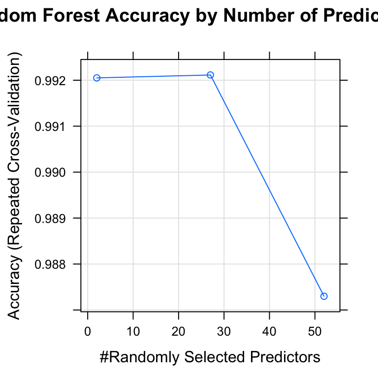

```r
plot(rf_fit, main = "Random Forest Accuracy by Number of Predictors")
```

Print confusion matrix for random forest model

```r
pred_rf <- predict(rf_fit, newdata = testing)
conf_rf <- confusionMatrix(pred_rf, testing$classe)
conf_rf
```

```
## Confusion Matrix and Statistics
##
##           Reference
## Prediction    A    B    C    D    E
##          A 1115   10    0    0    0
##          B    0  747    1    0    1
##          C    0    2  680    5    1
##          D    0    0    3  638    0
##          E    1    0    0    0  719
##
## Overall Statistics
##
##                Accuracy : 0.994
##                  95% CI : (0.991, 0.996)
##     No Information Rate : 0.284
##     P-Value [Acc > NIR] : <2e-16
##
##                   Kappa : 0.992
##
##  Mcnemar's Test P-Value : NA
##
## Statistics by Class:
##
##                      Class: A Class: B Class: C Class: D Class: E
## Sensitivity             0.999    0.984    0.994    0.992    0.997
## Specificity             0.996    0.999    0.998    0.999    1.000
## Pos Pred Value          0.991    0.997    0.988    0.995    0.999
## Neg Pred Value          1.000    0.996    0.999    0.998    0.999
## Prevalence              0.284    0.193    0.174    0.164    0.184
## Detection Rate          0.284    0.190    0.173    0.163    0.183
## Detection Prevalence    0.287    0.191    0.175    0.163    0.184
## Balanced Accuracy       0.998    0.992    0.996    0.996    0.998
```

The random forest model overall accuracy is 99.3882%, significanlty greater than the linear discriminant analysis model.

Final Model and Variable Importance List

```r
rf_fit$finalModel
```

```
##
## Call:
##  randomForest(x = x, y = y, mtry = param$mtry)
##                Type of random forest: classification
##                      Number of trees: 500
## No. of variables tried at each split: 27
##
##         OOB estimate of  error rate: 0.62%
## Confusion matrix:
##      A    B    C    D    E class.error
## A 4454    6    3    0    1    0.002240
## B   17 3013    7    1    0    0.008229
## C    0   11 2718    9    0    0.007305
## D    0    0   27 2544    2    0.011271
## E    0    0    7    7 2872    0.004851
```

```r
varImp(rf_fit)
```

```
## rf variable importance
##
##   only 20 most important variables shown (out of 52)
##
##                      Overall
## roll_belt              100.0
## pitch_forearm           59.5
## yaw_belt                53.6
## pitch_belt              45.7
## magnet_dumbbell_z       44.9
## magnet_dumbbell_y       42.4
## roll_forearm            41.4
## accel_dumbbell_y        20.7
## accel_forearm_x         17.6
## roll_dumbbell           17.2
## magnet_dumbbell_x       16.8
## accel_dumbbell_z        14.7
## magnet_belt_z           14.0
## magnet_forearm_z        13.1
## accel_belt_z            13.1
## total_accel_dumbbell    13.1
## magnet_belt_y           11.9
## yaw_arm                 10.7
## gyros_belt_z            10.5
## magnet_belt_x           10.4
```

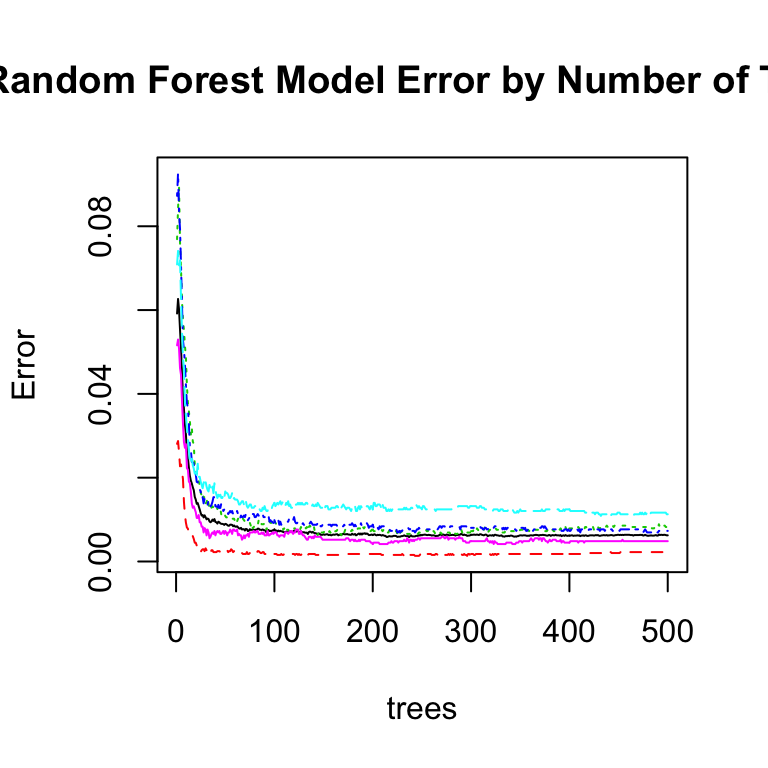

```r
plot(rf_fit$finalModel, main = "Random Forest Model Error by Number of Trees")
```

## Train model: gradient boosted method (gbm)

```r
gbmControl <- trainControl(method = "repeatedcv",
                           number = 5,
                           repeats = 5,
                           allowParallel = TRUE)

set.seed(105)
gbmfit <- train(classe ~ ., data = training,
                method = "gbm",
                trControl = gbmControl,
                verbose = FALSE)
gbmfit
```

```
## Stochastic Gradient Boosting
##
## 15699 samples
##    52 predictor
##     5 classes: 'A', 'B', 'C', 'D', 'E'
##
## No pre-processing
## Resampling: Cross-Validated (5 fold, repeated 5 times)
## Summary of sample sizes: 12558, 12561, 12558, 12559, 12560, 12558, ...
## Resampling results across tuning parameters:
##
##   interaction.depth  n.trees  Accuracy  Kappa
##   1                   50      0.7496    0.6825
##   1                  100      0.8182    0.7699
##   1                  150      0.8523    0.8130
##   2                   50      0.8547    0.8159
##   2                  100      0.9079    0.8834
##   2                  150      0.9327    0.9148
##   3                   50      0.8983    0.8712
##   3                  100      0.9438    0.9289
##   3                  150      0.9622    0.9521
##
## Tuning parameter 'shrinkage' was held constant at a value of 0.1
##
## Tuning parameter 'n.minobsinnode' was held constant at a value of 10
## Accuracy was used to select the optimal model using the largest value.
## The final values used for the model were n.trees = 150,
##  interaction.depth = 3, shrinkage = 0.1 and n.minobsinnode = 10.
```

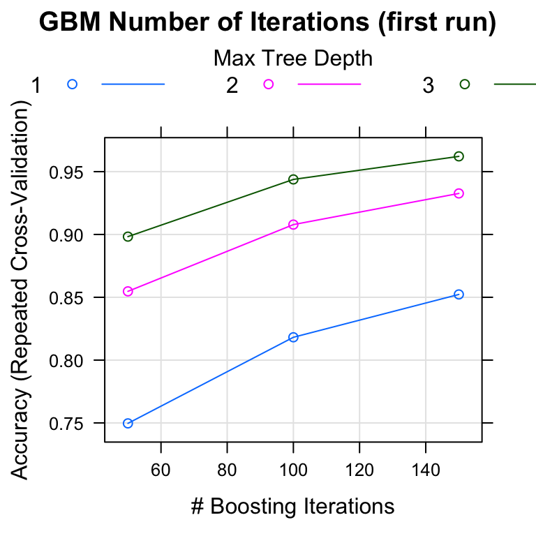

```r
plot(gbmfit, main = "GBM Number of Iterations (first run)")
```

```r
## model tuning
gbmGrid <-  expand.grid(interaction.depth = c(1, 3, 5, 7),
                        n.trees = (1:10)*50,
                        shrinkage = 0.1,
                        n.minobsinnode = 10)

gbmfit_f <- train(classe ~ ., data = training,
                method = "gbm",
                trControl = gbmControl,
                verbose = FALSE,
                tuneGrid = gbmGrid)
gbmfit_f
```

```
## Stochastic Gradient Boosting
##
## 15699 samples
##    52 predictor
##     5 classes: 'A', 'B', 'C', 'D', 'E'
##
## No pre-processing
## Resampling: Cross-Validated (5 fold, repeated 5 times)
## Summary of sample sizes: 12559, 12558, 12559, 12560, 12560, 12560, ...
## Resampling results across tuning parameters:
##
##   interaction.depth  n.trees  Accuracy  Kappa
##   1                   50      0.7504    0.6835
##   1                  100      0.8188    0.7707
##   1                  150      0.8521    0.8129
```

[output cut: 44 more lines]

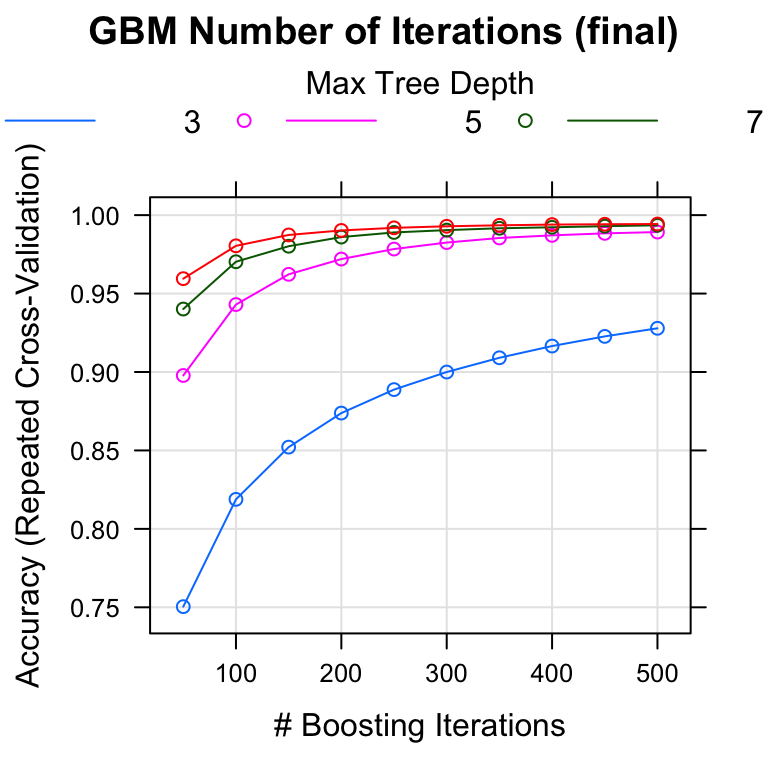

```r
plot(gbmfit_f, main = "GBM Number of Iterations (final)")
```

Print confusion matrix and accuracy for gbm model

```r
pred_gbm <- predict(gbmfit_f, newdata = testing)
conf_gbm <- confusionMatrix(pred_gbm, testing$classe)
conf_gbm
```

```
## Confusion Matrix and Statistics
##
##           Reference
## Prediction    A    B    C    D    E
##          A 1116    7    0    0    0
##          B    0  750    3    0    1
##          C    0    2  680    3    1
##          D    0    0    1  639    1
##          E    0    0    0    1  718
##
## Overall Statistics
##
##                Accuracy : 0.995
##                  95% CI : (0.992, 0.997)
##     No Information Rate : 0.284
##     P-Value [Acc > NIR] : <2e-16
##
##                   Kappa : 0.994
##
##  Mcnemar's Test P-Value : NA
##
## Statistics by Class:
##
##                      Class: A Class: B Class: C Class: D Class: E
## Sensitivity             1.000    0.988    0.994    0.994    0.996
## Specificity             0.998    0.999    0.998    0.999    1.000
## Pos Pred Value          0.994    0.995    0.991    0.997    0.999
## Neg Pred Value          1.000    0.997    0.999    0.999    0.999
## Prevalence              0.284    0.193    0.174    0.164    0.184
## Detection Rate          0.284    0.191    0.173    0.163    0.183
## Detection Prevalence    0.286    0.192    0.175    0.163    0.183
## Balanced Accuracy       0.999    0.993    0.996    0.997    0.998
```

## Conclusion

The gradient boosted method (gbm) model overall accuracy is 99.4902%, significanlty greater than the linear discriminant analysis model and slightly better than the randon forest model. This is the best model and will be applied to predict the classe variable in the test dataset (test_clean).

```r
final_pred <- predict(gbmfit_f, newdata = test_clean)
final_pred
```

```
##  [1] B A B A A E D B A A B C B A E E A B B B
## Levels: A B C D E
```

De-provision parallel cluster

```r
stopCluster(cl)
registerDoSEQ()
```

References:

Velloso, E.; Bulling, A.; Gellersen, H.; Ugulino, W.; Fuks, H. Qualitative Activity Recognition of Weight Lifting Exercises. Proceedings of 4th International Conference in Cooperation with SIGCHI (Augmented Human ’13) . Stuttgart, Germany: ACM SIGCHI, 2013.

Read more: http://groupware.les.inf.puc-rio.br/har#ixzz5wKbTlgFa